# Customer Churn

```python
import pandas as pd
import matplotlib.pyplot as plt
import seaborn as sns
import numpy as np

# Classifier Algorithms Libraries
from sklearn.linear_model import SGDClassifier
from sklearn.neighbors import KNeighborsClassifier
from sklearn.ensemble import RandomForestClassifier
from sklearn.linear_model import LogisticRegression
from sklearn.svm import SVC
from sklearn.ensemble import GradientBoostingClassifier
from sklearn.model_selection import train_test_split
from sklearn.metrics import accuracy_score, precision_score, recall_score,f1_score,roc_auc_score
from sklearn.metrics import confusion_matrix
from sklearn.tree import DecisionTreeClassifier
from xgboost import XGBClassifier
from sklearn.naive_bayes import GaussianNB
from sklearn.preprocessing import StandardScaler

import warnings
warnings.filterwarnings('ignore')
```

```python
# Load Dataset

df = pd.read_csv("C:\\Users\\HP\\Desktop\\CAPSTONE Project.csv")
```

```python
# The Top Rows

df.head()
```

|  | customerID | gender | SeniorCitizen | Partner | Dependents | tenure | PhoneService | MultipleLines | InternetService | OnlineSecurity | ... | DeviceProtection | TechSupport | StreamingTV | StreamingMovies | Contract | PaperlessBilling | PaymentMethod | MonthlyCharges | TotalCharges | Churn |
| --- | --- | --- | --- | --- | --- | --- | --- | --- | --- | --- | --- | --- | --- | --- | --- | --- | --- | --- | --- | --- | --- |
| 0 | 7590-VHVEG | Female | 0 | Yes | No | 1 | No | No phone service | DSL | No | ... | No | No | No | No | Month-to-month | Yes | Electronic check | 29.85 | 29.85 | No |
| 1 | 5575-GNVDE | Male | 0 | No | No | 34 | Yes | No | DSL | Yes | ... | Yes | No | No | No | One year | No | Mailed check | 56.95 | 1889.5 | No |
| 2 | 3668-QPYBK | Male | 0 | No | No | 2 | Yes | No | DSL | Yes | ... | No | No | No | No | Month-to-month | Yes | Mailed check | 53.85 | 108.15 | Yes |
| 3 | 7795-CFOCW | Male | 0 | No | No | 45 | No | No phone service | DSL | Yes | ... | Yes | Yes | No | No | One year | No | Bank transfer (automatic) | 42.30 | 1840.75 | No |
| 4 | 9237-HQITU | Female | 0 | No | No | 2 | Yes | No | Fiber optic | No | ... | No | No | No | No | Month-to-month | Yes | Electronic check | 70.70 | 151.65 | Yes |

5 rows × 21 columns

```python
# The Bottom Rows

df.tail()
```

|  | customerID | gender | SeniorCitizen | Partner | Dependents | tenure | PhoneService | MultipleLines | InternetService | OnlineSecurity | ... | DeviceProtection | TechSupport | StreamingTV | StreamingMovies | Contract | PaperlessBilling | PaymentMethod | MonthlyCharges | TotalCharges | Churn |
| --- | --- | --- | --- | --- | --- | --- | --- | --- | --- | --- | --- | --- | --- | --- | --- | --- | --- | --- | --- | --- | --- |
| 7038 | 6840-RESVB | Male | 0 | Yes | Yes | 24 | Yes | Yes | DSL | Yes | ... | Yes | Yes | Yes | Yes | One year | Yes | Mailed check | 84.80 | 1990.5 | No |
| 7039 | 2234-XADUH | Female | 0 | Yes | Yes | 72 | Yes | Yes | Fiber optic | No | ... | Yes | No | Yes | Yes | One year | Yes | Credit card (automatic) | 103.20 | 7362.9 | No |
| 7040 | 4801-JZAZL | Female | 0 | Yes | Yes | 11 | No | No phone service | DSL | Yes | ... | No | No | No | No | Month-to-month | Yes | Electronic check | 29.60 | 346.45 | No |
| 7041 | 8361-LTMKD | Male | 1 | Yes | No | 4 | Yes | Yes | Fiber optic | No | ... | No | No | No | No | Month-to-month | Yes | Mailed check | 74.40 | 306.6 | Yes |
| 7042 | 3186-AJIEK | Male | 0 | No | No | 66 | Yes | No | Fiber optic | Yes | ... | Yes | Yes | Yes | Yes | Two year | Yes | Bank transfer (automatic) | 105.65 | 6844.5 | No |

5 rows × 21 columns

```python
# Dimensionality of the data - the number of rows and columns
df.shape
```

```
(7043, 21)
```

```python
# Examine the columns/ features of the data
df.columns
```

```
Index(['customerID', 'gender', 'SeniorCitizen', 'Partner', 'Dependents',
       'tenure', 'PhoneService', 'MultipleLines', 'InternetService',
       'OnlineSecurity', 'OnlineBackup', 'DeviceProtection', 'TechSupport',
       'StreamingTV', 'StreamingMovies', 'Contract', 'PaperlessBilling',
       'PaymentMethod', 'MonthlyCharges', 'TotalCharges', 'Churn'],
      dtype='object')
```

```python
# investigate the dataset for anomalies and data types
df.info()
```

```
<class 'pandas.core.frame.DataFrame'>
RangeIndex: 7043 entries, 0 to 7042
Data columns (total 21 columns):
 #   Column            Non-Null Count  Dtype
---  ------            --------------  -----
 0   customerID        7043 non-null   object
 1   gender            7043 non-null   object
 2   SeniorCitizen     7043 non-null   int64
 3   Partner           7043 non-null   object
 4   Dependents        7043 non-null   object
 5   tenure            7043 non-null   int64
 6   PhoneService      7043 non-null   object
 7   MultipleLines     7043 non-null   object
 8   InternetService   7043 non-null   object
 9   OnlineSecurity    7043 non-null   object
 10  OnlineBackup      7043 non-null   object
 11  DeviceProtection  7043 non-null   object
 12  TechSupport       7043 non-null   object
 13  StreamingTV       7043 non-null   object
 14  StreamingMovies   7043 non-null   object
 15  Contract          7043 non-null   object
 16  PaperlessBilling  7043 non-null   object
 17  PaymentMethod     7043 non-null   object
 18  MonthlyCharges    7043 non-null   float64
 19  TotalCharges      7043 non-null   object
 20  Churn             7043 non-null   object
dtypes: float64(1), int64(2), object(18)
memory usage: 1.1+ MB
```

```
customerID          0
gender              0
SeniorCitizen       0
Partner             0
Dependents          0
tenure              0
PhoneService        0
MultipleLines       0
InternetService     0
OnlineSecurity      0
OnlineBackup        0
DeviceProtection    0
TechSupport         0
StreamingTV         0
StreamingMovies     0
Contract            0
PaperlessBilling    0
PaymentMethod       0
MonthlyCharges      0
TotalCharges        0
Churn               0
Tenure_Segment      0
dtype: int64
```

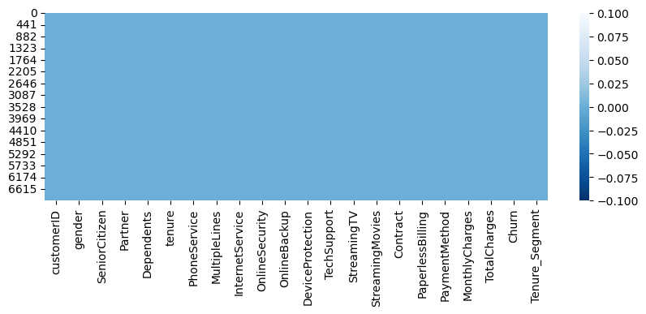

```python
# Visualizing for missing values

print(df.isnull().sum())
plt.figure(figsize = (10, 3))
sns.heatmap(df.isnull(), cbar=True, cmap='Blues_r')
```

```python
# Numerical Statistical Analysis
df.describe()
```

|  | SeniorCitizen | tenure | MonthlyCharges |
| --- | --- | --- | --- |
| count | 7043.000000 | 7043.000000 | 7043.000000 |
| mean | 0.162147 | 32.371149 | 64.761692 |
| std | 0.368612 | 24.559481 | 30.090047 |
| min | 0.000000 | 0.000000 | 18.250000 |
| 25% | 0.000000 | 9.000000 | 35.500000 |
| 50% | 0.000000 | 29.000000 | 70.350000 |
| 75% | 0.000000 | 55.000000 | 89.850000 |
| max | 1.000000 | 72.000000 | 118.750000 |

```python
# Categorical Statistical Analysis

df.describe(include=["object", "bool"])
```

|  | customerID | gender | Partner | Dependents | PhoneService | MultipleLines | InternetService | OnlineSecurity | OnlineBackup | DeviceProtection | TechSupport | StreamingTV | StreamingMovies | Contract | PaperlessBilling | PaymentMethod | TotalCharges | Churn |
| --- | --- | --- | --- | --- | --- | --- | --- | --- | --- | --- | --- | --- | --- | --- | --- | --- | --- | --- |
| count | 7043 | 7043 | 7043 | 7043 | 7043 | 7043 | 7043 | 7043 | 7043 | 7043 | 7043 | 7043 | 7043 | 7043 | 7043 | 7043 | 7043 | 7043 |
| unique | 7043 | 2 | 2 | 2 | 2 | 3 | 3 | 3 | 3 | 3 | 3 | 3 | 3 | 3 | 2 | 4 | 6531 | 2 |
| top | 7590-VHVEG | Male | No | No | Yes | No | Fiber optic | No | No | No | No | No | No | Month-to-month | Yes | Electronic check |  | No |
| freq | 1 | 3555 | 3641 | 4933 | 6361 | 3390 | 3096 | 3498 | 3088 | 3095 | 3473 | 2810 | 2785 | 3875 | 4171 | 2365 | 11 | 5174 |

### Exploratory Data Analysis (EDA)

### Univariate Analysis

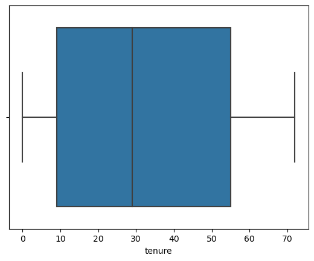

```python
# check for outlier
sns.boxplot(x=df["tenure"]);
```

```
Churn
No     5174
Yes    1869
Name: count, dtype: int64
```

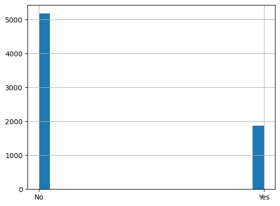

```python
#  Visualization for Churn

print(df["Churn"].value_counts())
df['Churn'].hist(bins=20,);
```

```
Tenure_Segment
New             3210
Long Term       2239
Intermediate    1594
Name: count, dtype: int64
```

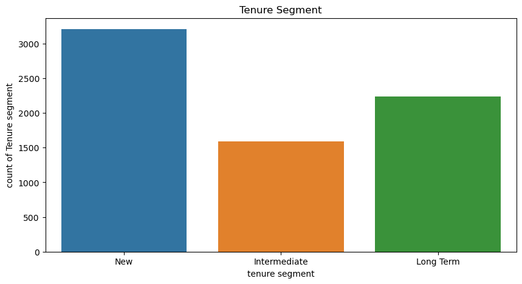

```python
# Tenure Segmentation

def Tenure_Segment(tenure):
    if tenure <= 24:
        return "New"
    elif tenure <= 48:
        return "Intermediate"
    else:
        return "Long Term"

df["Tenure_Segment"] = df["tenure"].apply(Tenure_Segment)

print(df["Tenure_Segment"].value_counts())
plt.figure(figsize = (10, 5))
sns.countplot(x='Tenure_Segment', data=df)
plt.xlabel('tenure segment')
plt.ylabel('count of Tenure segment')
plt.title( 'Tenure Segment');
```

```python
df.head()
```

|  | customerID | gender | SeniorCitizen | Partner | Dependents | tenure | PhoneService | MultipleLines | InternetService | OnlineSecurity | ... | DeviceProtection | TechSupport | StreamingTV | StreamingMovies | Contract | PaperlessBilling | PaymentMethod | MonthlyCharges | TotalCharges | Churn |
| --- | --- | --- | --- | --- | --- | --- | --- | --- | --- | --- | --- | --- | --- | --- | --- | --- | --- | --- | --- | --- | --- |
| 0 | 7590-VHVEG | Female | 0 | Yes | No | 1 | No | No phone service | DSL | No | ... | No | No | No | No | Month-to-month | Yes | Electronic check | 29.85 | 29.85 | No |
| 1 | 5575-GNVDE | Male | 0 | No | No | 34 | Yes | No | DSL | Yes | ... | Yes | No | No | No | One year | No | Mailed check | 56.95 | 1889.5 | No |
| 2 | 3668-QPYBK | Male | 0 | No | No | 2 | Yes | No | DSL | Yes | ... | No | No | No | No | Month-to-month | Yes | Mailed check | 53.85 | 108.15 | Yes |
| 3 | 7795-CFOCW | Male | 0 | No | No | 45 | No | No phone service | DSL | Yes | ... | Yes | Yes | No | No | One year | No | Bank transfer (automatic) | 42.30 | 1840.75 | No |
| 4 | 9237-HQITU | Female | 0 | No | No | 2 | Yes | No | Fiber optic | No | ... | No | No | No | No | Month-to-month | Yes | Electronic check | 70.70 | 151.65 | Yes |

5 rows × 21 columns

```
Gender_Classification
Male      3555
Female    3488
Name: count, dtype: int64
```

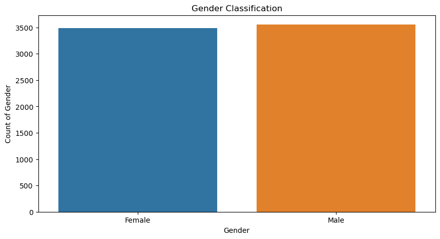

```python
def Gender_Classification(gender):
    if gender <= 0:
        return "Female"
    else:
        return "Male"

df["Gender_Classification"] = df["gender"].apply(Gender_Classification)

print(df["Gender_Classification"].value_counts())
plt.figure(figsize = (10, 5))
sns.countplot(x='Gender_Classification', data=df)
plt.xlabel('Gender')
plt.ylabel('Count of Gender')
plt.title( 'Gender Classification');
```

```
SeniorCitizen
0    5901
1    1142
Name: count, dtype: int64
```

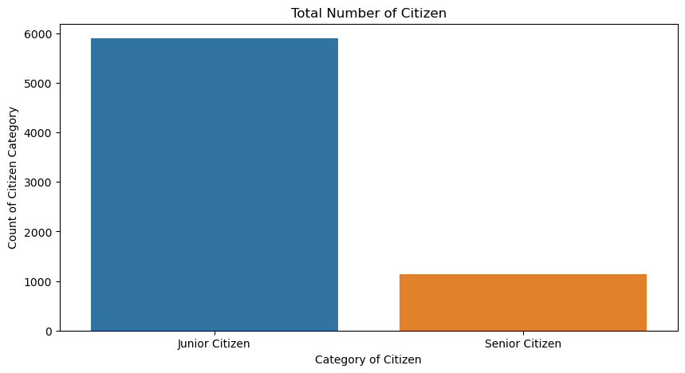

```python
def SeniorCitizen(sc):
    if sc == 1:
        return "Senior Citizen"
    else:
        return "Junior Citizen"

print(df["SeniorCitizen"].value_counts())
df['sc'] = df['SeniorCitizen'].apply(SeniorCitizen)

plt.figure(figsize = (10, 5))
sns.countplot(x='sc', data=df)
plt.xlabel('Category of Citizen')
plt.ylabel('Count of Citizen Category')
plt.title( 'Total Number of Citizen');
```

```
InternetService
Fiber optic    3096
DSL            2421
No             1526
Name: count, dtype: int64
```

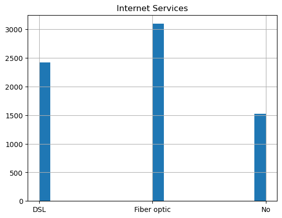

```python
# Convert the "InternetService" column to string

df['InternetService'] = df['InternetService'].astype(str)

print(df["InternetService"].value_counts())
df['InternetService'].hist(bins=20,)
plt.title( 'Internet Services');
```

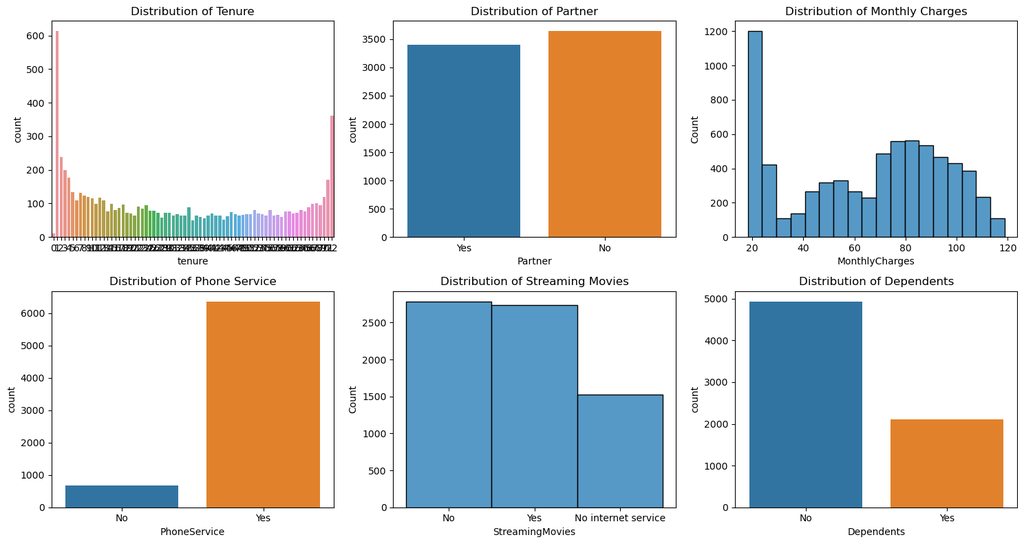

```python
# Subplot Visualization of Tenure, Partner, Monthly Charges, Phone Services, Streaming Movies, Dependents.

fig, axs = plt.subplots(2, 3, figsize=(15, 8))

plt1 = sns.countplot(x='tenure', data=df, ax=axs[0, 0])
plt1.set_title('Distribution of Tenure')

plt2 = sns.countplot(x='Partner', data=df, ax=axs[0, 1])
plt2.set_title('Distribution of Partner')

plt3 = sns.histplot(df['MonthlyCharges'], ax=axs[0, 2])
plt3.set_title('Distribution of Monthly Charges')

plt4 = sns.countplot(x='PhoneService', data=df, ax=axs[1, 0])
plt4.set_title('Distribution of Phone Service')

plt5 = sns.histplot(x='StreamingMovies', data=df, ax=axs[1, 1])
plt5.set_title('Distribution of Streaming Movies')

plt6 = sns.countplot(x='Dependents', data=df, ax=axs[1, 2])
plt6.set_title('Distribution of Dependents')

plt.tight_layout()
plt.show()
```

### Bivariate Analysis

[output not shown]

[figure not shown]

```python
# Investigating relationship between Gender and Churn

# Bar plot using seaborn
sns.countplot(x='gender', hue='Churn', data=df)

# Set plot labels and title
plt.xlabel('gender')
plt.ylabel('Count')
plt.title('Churn by gender')

# Show the plot
plt.show()
```

A bar plot visualizing the Churn rates between male and female customers with variable of interest as Churn and Gender indicates a lower churn rate among both gender within the telecom customer dataset.

it is observed that the churn rates, representing the proportion of customers who discontinued services, differ slightly between genders. while, the Churn rate is low in both gender, the Non-Churn rate is high.

```
Tenure_Segment
New             3210
Long Term       2239
Intermediate    1594
Name: count, dtype: int64
```

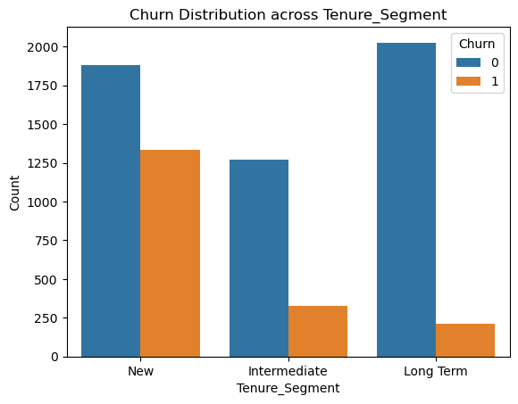

```python
# Investigating relationship between Tenure and Churn

# Bar plot using seaborn
sns.countplot(x='Tenure_Segment', hue='Churn', data=df)

print(df["Tenure_Segment"].value_counts())

# Set plot labels and title
plt.xlabel('Tenure_Segment')
plt.ylabel('Count')
plt.title('Churn Distribution across Tenure_Segment')

# Show the plot
plt.show()
```

Churn Distribution Across Tenure Segments:

The bar plot illustrates the distribution of churn within different tenure segments.Noticeable differences in the count of churners and non-churners across tenure segments can be observed.

it is observed that the New tenure segments exhibit higher churn rates compared to others. it is observed that the longer the tenure the lower the Churn and the lower the tenure the higher the Churn (see analysis below).

T_S Non-Churn Churn New 58% 42% Intermediate 78% 22% LongTerm 89% 11%

The New tenure segment may require targeted retention efforts.

In conclusion, our analysis underscores the pivotal role of tenure in understanding and predicting customer churn. As tenure increases, the likelihood of churn decreases, emphasizing the importance of fostering customer loyalty, especially during the early stages of the customer relationship.

```python
df.head()
```

|  | customerID | gender | SeniorCitizen | Partner | Dependents | tenure | PhoneService | MultipleLines | InternetService | OnlineSecurity | ... | DeviceProtection | TechSupport | StreamingTV | StreamingMovies | Contract | PaperlessBilling | PaymentMethod | MonthlyCharges | TotalCharges | Churn |
| --- | --- | --- | --- | --- | --- | --- | --- | --- | --- | --- | --- | --- | --- | --- | --- | --- | --- | --- | --- | --- | --- |
| 0 | 7590-VHVEG | Female | 0 | Yes | No | 1 | No | No phone service | DSL | No | ... | No | No | No | No | Month-to-month | Yes | Electronic check | 29.85 | 29.85 | No |
| 1 | 5575-GNVDE | Male | 0 | No | No | 34 | Yes | No | DSL | Yes | ... | Yes | No | No | No | One year | No | Mailed check | 56.95 | 1889.5 | No |
| 2 | 3668-QPYBK | Male | 0 | No | No | 2 | Yes | No | DSL | Yes | ... | No | No | No | No | Month-to-month | Yes | Mailed check | 53.85 | 108.15 | Yes |
| 3 | 7795-CFOCW | Male | 0 | No | No | 45 | No | No phone service | DSL | Yes | ... | Yes | Yes | No | No | One year | No | Bank transfer (automatic) | 42.30 | 1840.75 | No |
| 4 | 9237-HQITU | Female | 0 | No | No | 2 | Yes | No | Fiber optic | No | ... | No | No | No | No | Month-to-month | Yes | Electronic check | 70.70 | 151.65 | Yes |

5 rows × 21 columns

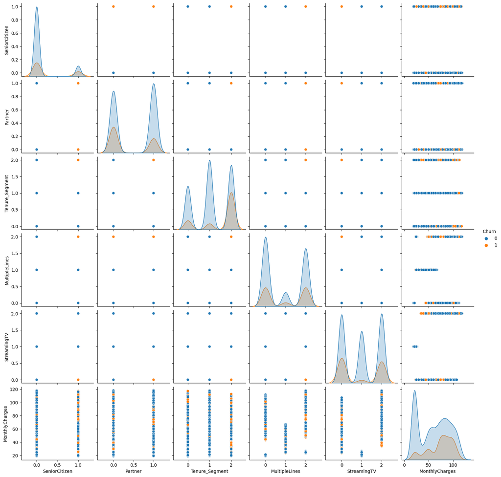

```python
# Bivariate analysis - Pairplot
plt.figure(figsize=(6,4))
columns_to_check = ["SeniorCitizen", "Partner", "Tenure_Segment", "MultipleLines", "StreamingTV", "MonthlyCharges", "Churn"]
sns.pairplot(df[columns_to_check], hue="Churn")
plt.show()
```

##### Multivariate Analysis

[figure not shown]

```python
# Multivariate analysis - Correlation Heatmap

correlation_table = df[columns_to_check].corr()

sns.heatmap(correlation_table, annot=True)
plt.show()
```

```python
df.head()
```

|  | customerID | gender | SeniorCitizen | Partner | Dependents | tenure | PhoneService | MultipleLines | InternetService | OnlineSecurity | ... | TechSupport | StreamingTV | StreamingMovies | Contract | PaperlessBilling | PaymentMethod | MonthlyCharges | TotalCharges | Churn | Tenure_Segment |
| --- | --- | --- | --- | --- | --- | --- | --- | --- | --- | --- | --- | --- | --- | --- | --- | --- | --- | --- | --- | --- | --- |
| 0 | 5375 | 0 | 0 | 1 | 0 | 1 | 0 | 1 | 0 | 0 | ... | 0 | 0 | 0 | 0 | 1 | 2 | 29.85 | 2505 | 0 | 2 |
| 1 | 3962 | 1 | 0 | 0 | 0 | 34 | 1 | 0 | 0 | 2 | ... | 0 | 0 | 0 | 1 | 0 | 3 | 56.95 | 1466 | 0 | 0 |
| 2 | 2564 | 1 | 0 | 0 | 0 | 2 | 1 | 0 | 0 | 2 | ... | 0 | 0 | 0 | 0 | 1 | 3 | 53.85 | 157 | 1 | 2 |
| 3 | 5535 | 1 | 0 | 0 | 0 | 45 | 0 | 1 | 0 | 2 | ... | 2 | 0 | 0 | 1 | 0 | 0 | 42.30 | 1400 | 0 | 0 |
| 4 | 6511 | 0 | 0 | 0 | 0 | 2 | 1 | 0 | 1 | 0 | ... | 0 | 0 | 0 | 0 | 1 | 2 | 70.70 | 925 | 1 | 2 |

5 rows × 22 columns

### Future Engineering/ Data Pre-Processing

```python
df.head()
```

|  | customerID | gender | SeniorCitizen | Partner | Dependents | tenure | PhoneService | MultipleLines | InternetService | OnlineSecurity | ... | TechSupport | StreamingTV | StreamingMovies | Contract | PaperlessBilling | PaymentMethod | MonthlyCharges | TotalCharges | Churn | Tenure_Segment |
| --- | --- | --- | --- | --- | --- | --- | --- | --- | --- | --- | --- | --- | --- | --- | --- | --- | --- | --- | --- | --- | --- |
| 0 | 5375 | 0 | 0 | 1 | 0 | 1 | 0 | 1 | 0 | 0 | ... | 0 | 0 | 0 | 0 | 1 | 2 | 29.85 | 2505 | 0 | 2 |
| 1 | 3962 | 1 | 0 | 0 | 0 | 34 | 1 | 0 | 0 | 2 | ... | 0 | 0 | 0 | 1 | 0 | 3 | 56.95 | 1466 | 0 | 0 |
| 2 | 2564 | 1 | 0 | 0 | 0 | 2 | 1 | 0 | 0 | 2 | ... | 0 | 0 | 0 | 0 | 1 | 3 | 53.85 | 157 | 1 | 2 |
| 3 | 5535 | 1 | 0 | 0 | 0 | 45 | 0 | 1 | 0 | 2 | ... | 2 | 0 | 0 | 1 | 0 | 0 | 42.30 | 1400 | 0 | 0 |
| 4 | 6511 | 0 | 0 | 0 | 0 | 2 | 1 | 0 | 1 | 0 | ... | 0 | 0 | 0 | 0 | 1 | 2 | 70.70 | 925 | 1 | 2 |

5 rows × 22 columns

```python
df1 = df[["gender", "SeniorCitizen", "Partner", "Dependents", "tenure",  "PhoneService", "MultipleLines", "InternetService", "OnlineSecurity", "TechSupport", "StreamingTV", "StreamingMovies", "Contract", "PaperlessBilling", "PaymentMethod", "MonthlyCharges", "TotalCharges"]]

label = df[['Churn']]
```

```python
df.head()
```

|  | customerID | gender | SeniorCitizen | Partner | Dependents | tenure | PhoneService | MultipleLines | InternetService | OnlineSecurity | ... | TechSupport | StreamingTV | StreamingMovies | Contract | PaperlessBilling | PaymentMethod | MonthlyCharges | TotalCharges | Churn | Tenure_Segment |
| --- | --- | --- | --- | --- | --- | --- | --- | --- | --- | --- | --- | --- | --- | --- | --- | --- | --- | --- | --- | --- | --- |
| 0 | 5375 | 0 | 0 | 1 | 0 | 1 | 0 | 1 | 0 | 0 | ... | 0 | 0 | 0 | 0 | 1 | 2 | 29.85 | 2505 | 0 | 2 |
| 1 | 3962 | 1 | 0 | 0 | 0 | 34 | 1 | 0 | 0 | 2 | ... | 0 | 0 | 0 | 1 | 0 | 3 | 56.95 | 1466 | 0 | 0 |
| 2 | 2564 | 1 | 0 | 0 | 0 | 2 | 1 | 0 | 0 | 2 | ... | 0 | 0 | 0 | 0 | 1 | 3 | 53.85 | 157 | 1 | 2 |
| 3 | 5535 | 1 | 0 | 0 | 0 | 45 | 0 | 1 | 0 | 2 | ... | 2 | 0 | 0 | 1 | 0 | 0 | 42.30 | 1400 | 0 | 0 |
| 4 | 6511 | 0 | 0 | 0 | 0 | 2 | 1 | 0 | 1 | 0 | ... | 0 | 0 | 0 | 0 | 1 | 2 | 70.70 | 925 | 1 | 2 |

5 rows × 22 columns

```python
df1.dtypes
```

```
gender                int32
SeniorCitizen         int64
Partner               int32
Dependents            int32
tenure                int64
PhoneService          int32
MultipleLines         int32
InternetService       int32
OnlineSecurity        int32
TechSupport           int32
StreamingTV           int32
StreamingMovies       int32
Contract              int32
PaperlessBilling      int32
PaymentMethod         int32
MonthlyCharges      float64
TotalCharges          int32
dtype: object
```

### Machine Learning

```python
# split the data into training and testing sets

from sklearn.model_selection import train_test_split

X_train, X_test, y_train, y_test = train_test_split(df1, label, test_size=0.2, random_state=42)
```

```python
# Model Building

# Logistic Regression
lng = LogisticRegression()
lng.fit(X_train, y_train)
ly_pred = lng.predict(X_test)

print('Logistic Regression')
print('Accuracy:', accuracy_score(y_test,ly_pred))
print('Precision:', precision_score(y_test,ly_pred))
print('Recall:', recall_score(y_test,ly_pred))
print('F1-score:', f1_score(y_test,ly_pred))
print('AUC-ROC:', roc_auc_score(y_test,ly_pred))
```

```
Logistic Regression
Accuracy: 0.808374733853797
Precision: 0.6492753623188405
Recall: 0.6005361930294906
F1-score: 0.6239554317548746
AUC-ROC: 0.7418704131170618
```

```python
X_test
```

|  | gender | SeniorCitizen | Partner | Dependents | tenure | PhoneService | MultipleLines | InternetService | OnlineSecurity | TechSupport | StreamingTV | StreamingMovies | Contract | PaperlessBilling | PaymentMethod | MonthlyCharges | TotalCharges |
| --- | --- | --- | --- | --- | --- | --- | --- | --- | --- | --- | --- | --- | --- | --- | --- | --- | --- |
| 185 | 0 | 0 | 1 | 0 | 1 | 0 | 1 | 0 | 0 | 0 | 0 | 0 | 0 | 1 | 2 | 24.80 | 2044 |
| 2715 | 1 | 0 | 0 | 0 | 41 | 1 | 2 | 2 | 1 | 1 | 1 | 1 | 0 | 1 | 0 | 25.25 | 6522 |
| 3825 | 0 | 0 | 1 | 1 | 52 | 1 | 0 | 2 | 1 | 1 | 1 | 1 | 2 | 0 | 3 | 19.35 | 67 |
| 1807 | 0 | 0 | 0 | 0 | 1 | 1 | 0 | 1 | 0 | 0 | 0 | 0 | 0 | 0 | 2 | 76.35 | 5822 |
| 132 | 1 | 0 | 0 | 0 | 67 | 1 | 0 | 0 | 0 | 2 | 0 | 0 | 2 | 0 | 0 | 50.55 | 2837 |
| ... | ... | ... | ... | ... | ... | ... | ... | ... | ... | ... | ... | ... | ... | ... | ... | ... | ... |
| 6366 | 0 | 0 | 1 | 0 | 64 | 1 | 0 | 0 | 0 | 2 | 0 | 2 | 2 | 1 | 3 | 68.30 | 3716 |
| 315 | 1 | 0 | 1 | 1 | 51 | 1 | 2 | 1 | 2 | 2 | 2 | 2 | 1 | 0 | 1 | 110.05 | 4697 |
| 2439 | 1 | 0 | 1 | 1 | 17 | 1 | 0 | 2 | 1 | 1 | 1 | 1 | 1 | 0 | 0 | 19.90 | 2856 |
| 5002 | 0 | 0 | 1 | 1 | 69 | 0 | 1 | 0 | 2 | 0 | 0 | 2 | 2 | 1 | 1 | 43.95 | 2556 |
| 1161 | 1 | 0 | 0 | 1 | 1 | 0 | 1 | 0 | 0 | 0 | 0 | 0 | 0 | 1 | 3 | 31.35 | 2697 |

1409 rows × 17 columns

```python
ly_pred
```

```
array([1, 0, 0, ..., 0, 0, 1])
```

```python
y_test
```

|  | Churn |
| --- | --- |
| 185 | 1 |
| 2715 | 0 |
| 3825 | 0 |
| 1807 | 1 |
| 132 | 0 |
| ... | ... |
| 6366 | 0 |
| 315 | 0 |
| 2439 | 0 |
| 5002 | 0 |
| 1161 | 1 |

1409 rows × 1 columns

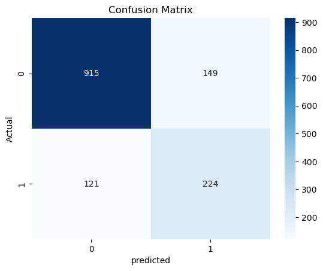

```python
# Confusion Matrix

lcm = confusion_matrix(ly_pred, y_test)

# Visualization in Confusion Matrix
sns.heatmap(lcm, annot=True,cmap = 'Blues', fmt = 'g')
plt.xlabel('predicted')
plt.ylabel('Actual')
plt.title('Confusion Matrix')
plt.show()
```

```python
# Random Forest Classifier

rfc = RandomForestClassifier()
rfc.fit(X_train, y_train)
rcm_pred = rfc.predict(X_test)

print('Random Forest Classifier')
print('Accuracy:', accuracy_score(y_test, rcm_pred))
print('Precision:', precision_score(y_test, rcm_pred))
print('Recall:', recall_score(y_test, rcm_pred))
print('F1-score:', f1_score(y_test, rcm_pred))
print('AUC-ROC:', roc_auc_score(y_test, rcm_pred))
```

```
Random Forest Classifier
Accuracy: 0.7920511000709723
Precision: 0.6492537313432836
Recall: 0.46648793565683644
F1-score: 0.5429017160686428
AUC-ROC: 0.6878771724616227
```

[figure not shown]

```python
# Random Forest Classifier

rfc = confusion_matrix(y_test,rcm_pred)

# Visualize the confusion matrix
sns.heatmap(rfc,annot=True,cmap='Blues',fmt='g')
plt.xlabel('predicted')
plt.ylabel('actual');
```

```python
# Decision Tree

Dtc = DecisionTreeClassifier()
Dtc.fit(X_train, y_train)
y_pred = Dtc.predict(X_test)

print('Decision Tree')
print('Accuracy:', accuracy_score(y_test,y_pred))
print('Precision:', precision_score(y_test,y_pred))
print('Recall:', recall_score(y_test,y_pred))
print('F1-score:', f1_score(y_test,y_pred))
print('AUC-ROC:', roc_auc_score(y_test,y_pred))
```

```
Decision Tree
Accuracy: 0.7324343506032647
Precision: 0.49444444444444446
Recall: 0.4772117962466488
F1-score: 0.48567530695770805
AUC-ROC: 0.6507680602854865
```

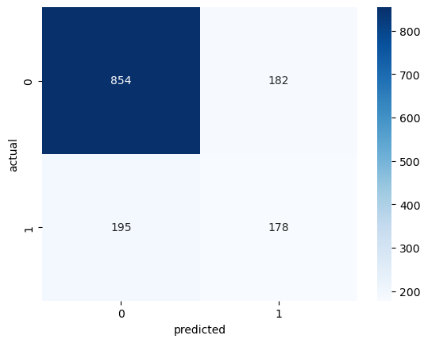

```python
dtc = confusion_matrix(y_test,y_pred)

# Visualize the confusion matrix
sns.heatmap(dtc,annot=True,cmap='Blues',fmt='g')
plt.xlabel('predicted')
plt.ylabel('actual');
```

```python
# SGDClassifier

SDG_Classifier = SGDClassifier()
SDG_Classifier.fit(X_train, y_train)
ly_pred = SDG_Classifier.predict(X_test)

print('SGDClassifier')
print('Accuracy:', accuracy_score(y_test,ly_pred))
print('Precision:', precision_score(y_test,ly_pred))
print('Recall:', recall_score(y_test,ly_pred))
print('F1-score:', f1_score(y_test,ly_pred))
print('AUC-ROC:', roc_auc_score(y_test,ly_pred))
```

```
SGDClassifier
Accuracy: 0.7217885024840313
Precision: 0.48408710217755446
Recall: 0.774798927613941
F1-score: 0.5958762886597938
AUC-ROC: 0.7387508151583217
```

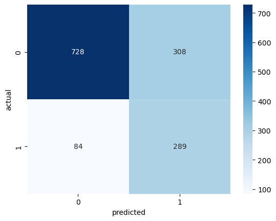

```python
SDG_Classifier = confusion_matrix(y_test,ly_pred)

# Visualize the confusion matrix
sns.heatmap(SDG_Classifier,annot=True,cmap='Blues',fmt='g')
plt.xlabel('predicted')
plt.ylabel('actual');
```

```python
# GradientBoostingClassifier

gbc = GradientBoostingClassifier()
gbc.fit(X_train, y_train)
gbc_pred = gbc.predict(X_test)

print('GradientBoostingClassifier')
print('Accuracy:', accuracy_score(y_test,gbc_pred))
print('Precision:', precision_score(y_test,gbc_pred))
print('Recall:', recall_score(y_test,gbc_pred))
print('F1-score:', f1_score(y_test,gbc_pred))
print('AUC-ROC:', roc_auc_score(y_test,gbc_pred))
```

```
GradientBoostingClassifier
Accuracy: 0.8126330731014905
Precision: 0.6885813148788927
Recall: 0.5335120643431636
F1-score: 0.6012084592145015
AUC-ROC: 0.7233197387352884
```

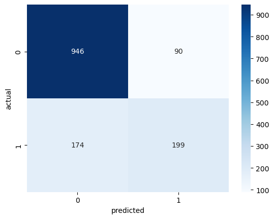

```python
gbc = confusion_matrix(y_test,gbc_pred)

# Visualize the confusion matrix
sns.heatmap(gbc,annot=True,cmap='Blues',fmt='g')
plt.xlabel('predicted')
plt.ylabel('actual');
```

```python
# SVC

Svo = SVC()
Svo.fit(X_train, y_train)
Svo_pred = Svo.predict(X_test)

print('SVC')
print('Accuracy:', accuracy_score(y_test,Svo_pred))
print('Precision:', precision_score(y_test,Svo_pred))
print('Recall:', recall_score(y_test,Svo_pred))
print('F1-score:', f1_score(y_test,Svo_pred))
print('AUC-ROC:', roc_auc_score(y_test,Svo_pred))
```

```
SVC
Accuracy: 0.7352732434350603
Precision: 0.0
Recall: 0.0
F1-score: 0.0
AUC-ROC: 0.5
```

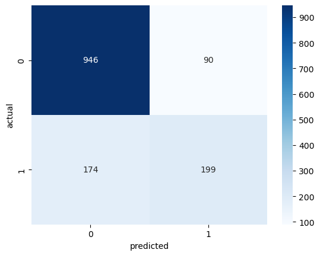

```python
Svo = confusion_matrix(y_test,Svo_pred)

# Visualize the confusion matrix
sns.heatmap(gbc,annot=True,cmap='Blues',fmt='g')
plt.xlabel('predicted')
plt.ylabel('actual');
```